# Discrimination

#### Background

Sometime around 1965 a survey was conducted where students at a certain university were asked the following question. “Do you think that some racial and religious groups should be prevented from living in certain sections of cities?” A summary of their response are recorded in the following table. The region of the United States that the student respondent was from was also recorded.

| Region | *Agree* | *Undecided* | *Disagree* |
| --- | --- | --- | --- |
| East | 89 | 79 | 297 |
| Midwest | 118 | 130 | 350 |
| South | 241 | 140 | 248 |
| West | 37 | 59 | 197 |

```r
discrim <- matrix(c(89,79,297,118,130,350,241,140,248,37,59,197), ncol = 3, byrow = T)
colnames(discrim) <- c("Agree","Undecided","Disagree")
rownames(discrim) <- c("East","Midwest","South","West")
```

## Question and Hypothesis

The question here is if the region a student is from affects their opinion on discrimination.

$H_0:$ The region and the opinion of the student are independent.  
$H_a:$ There is an association between the region and the opinion of the student.

## Graphics

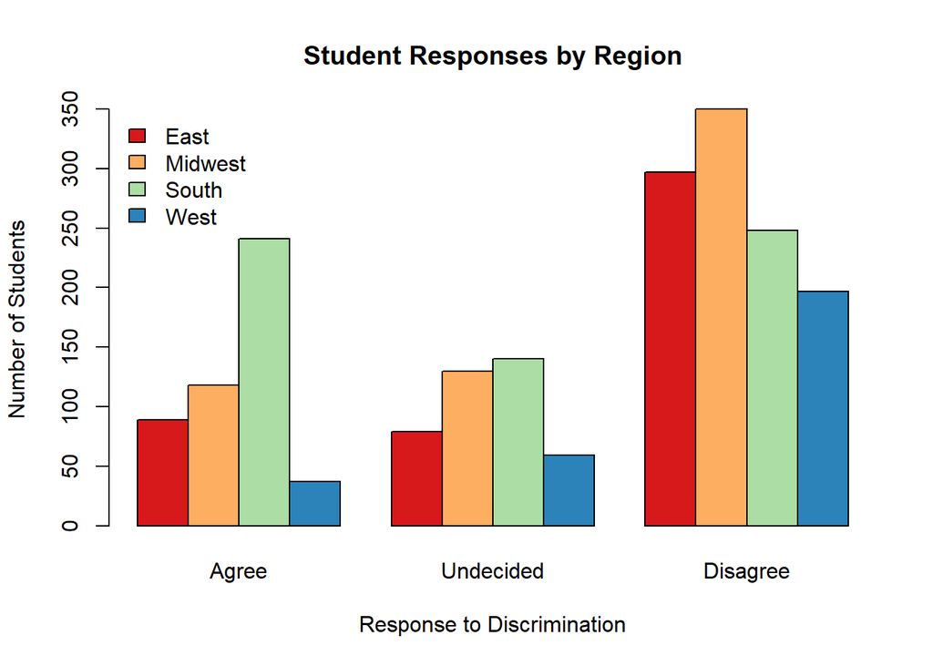

```r
barplot(discrim, main = "Student Responses by Region", xlab = "Response to Discrimination", ylab = "Number of Students", beside = TRUE, legend.text = TRUE, args.legend = list(x = "topleft", bty = "n"), col = brewer.pal(4,"Spectral"))
```

```r
#cols <- brewer.pal(8,"Set3")
#lapply(1:ncol(cols),function(x) lines(results[,x],col=cols[x],lwd=3))
```

This graph seems to indicate that region and opinion are not independent because there is not a pattern between each category.

In the Agree section, the South has the highest count of students. In the Disagree section, the highest count of students comes from the Midwest. However this is partially because more students are sampled from the South and the Midwest than the other two regions. For conclusive results, a test statistic must be used.

## Analysis

Running a chi-squared test yields the following results.

```r
chis <- chisq.test(discrim)
pander(chis)
```

Pearson’s Chi-squared test: `discrim`

| Test statistic | df | P value |
| --- | --- | --- |
| 125 | 6 | 1.476e-24 * * * |

The p-value is extremely small, leading to the conclusion that there is an association between region and the discrimination opinion of a student.

Before continuing, it’s important to check the appropriateness of using a chi-squared test on this data. The following table shows whether each expected value is greater than five.

```r
pander(chis$expected > 5)
```

|  | Agree | Undecided | Disagree |
| --- | --- | --- | --- |
| **East** | TRUE | TRUE | TRUE |
| **Midwest** | TRUE | TRUE | TRUE |
| **South** | TRUE | TRUE | TRUE |
| **West** | TRUE | TRUE | TRUE |

The expected values are all greater than five so the test is appropriate.

To discover the really interesting information, which regions are more or less prejudiced than expected, it’s important to look at the Pearson residuals.

```r
pander(chis$residuals)
```

|  | Agree | Undecided | Disagree |
| --- | --- | --- | --- |
| **East** | -2.309 | -1.696 | 2.575 |
| **Midwest** | -2.326 | 0.6392 | 1.159 |
| **South** | 7.043 | 0.9423 | -5.27 |
| **West** | -4.088 | -0.1577 | 2.821 |

The South is furthest from the expected values for both agree and disagree. Students in the South agree with discrimination much more than expected and disagree with discrimination much less than expected.

Every single other region has more students disagreeing with discrimination than expected. Of the four regions, the West is the furthest in this direction, having the highest positive Pearson residuals for Disagree.

For the Undecided group, the Pearson residuals are generally small, meaning that the numnber of students who were Undecided was about the same as expected.

From this it can be seen that students from the South are much more likely to agree with discrimination. Students from all other regions are more likely to disagree with discrimination.

## Interpretation

Overall, students from the South are the most likely to agree with discrimination. Since the South has historically been in favor of discrimination, these results make sense. Students from all other regions in the continental U.S. are more likely to disagree with discrimination, especially in the West.

Further studies might examine why each of the other regions disagree with discrimination more than expected.